# Data 607, Project 2, third part

Mehdi Khan

October 8, 2017

## Introduction:

This data was extracted from 2000 Census with information about race, rental and ownership of residences in Anne Arundel County, Maryland. The data was used by Anne Arundel County Community Development Services, Inc - a nonprofit agency in their housing research. I picked this data for the 3rd part of project 2.

The data was downloaded as an excel file which was converted to a CSV file, which then needed to be made tidy to do analysis in R. The analysis was done to see if the data could provide any relationship in race and ownership of residential properties.

## Load necessary libraries:

```r
library(stringr)
library(tidyr)
library(dplyr)
library(data.table)
```

```r
library(ggplot2)
```

## load data:

```r
houseDS <- read.csv("C:\\Temp\\race versus tenure of owner & rental housing units.csv",
    sep = ",", stringsAsFactors = FALSE, fill = TRUE)
str(houseDS)
```

```
## 'data.frame':    27 obs. of  3 variables:
##  $ X                  : chr  "Total:" " Owner occupied:" "  Householder who is White alone" "  Householder who is Black or African American alone" ...
##  $ Anne.Arundel.County: chr  "178,670" "134,922" "119,609" "11,615" ...
##  $ X.1                : logi  NA NA NA NA NA NA ...
```

Since data is distributed under two categories of ownership (rental and owned) two datsets were created with only relevant rows and columns, all other rows and columns were avoided:

```r
owned_houses <- houseDS[2:9, 1:2]
rental_houses <- houseDS[12:19, 1:2]
```

A funtion was created to do untidy operations on these two dataset, the function does the following: a. update with meaningful column names b. update race column with simplified race names c. add and populate new column with ownership information

```r
untidyData <- function(dat) {
    colnames(dat) <- c("race", "population")
    dat$population <- str_replace(dat$population, ",", "")

    dat$population <- as.numeric(dat$population)
    for (i in (1:length(dat$race))) {
        if (str_detect(dat$race[i], "White")) {
            dat$race[i] <- "White"
        } else if (str_detect(dat$race[i], "Black")) {
            dat$race[i] <- "African American"
        } else if (str_detect(dat$race[i], "Indian")) {
            dat$race[i] <- "American Indian and Alaska Native"
        } else if (str_detect(dat$race[i], "Asian")) {
            dat$race[i] <- "Asian"
        } else if (str_detect(dat$race[i], "Native")) {
            dat$race[i] <- "Native Hawaiian, Pacific Islander"
        } else if (str_detect(dat$race[i], "other race")) {
            dat$race[i] <- "Others"
        } else if (str_detect(dat$race[i], "Two or more")) {
            dat$race[i] <- " Two or more races"
        }
    }
    mutate(dat, ownership = "")
    if (str_detect(dat$race[1], "Owner") == TRUE) {
        dat$ownership <- "owner"
    } else if (str_detect(dat$race[1], "Renter")) {
        dat$ownership <- "renter"
    }

    dat <- dat[-1, ]

    ## dat$percentage=dat$population/sum(dat$population)

    return(dat)
}
owned_houses <- untidyData(owned_houses)
rental_houses <- untidyData(rental_houses)

HouseData <- rbind(owned_houses, rental_houses)

View(HouseData)
```

Some statistics:

```r
house_stat <- HouseData %>% group_by(ownership) %>% summarise(total_population = sum(population),
    max_population = max(population), race_max_occupancy = race[which.max(population)],
    min_population = min(population), race_min_occupancy = race[which.min(population)])

View(house_stat)
```

Figure 1:

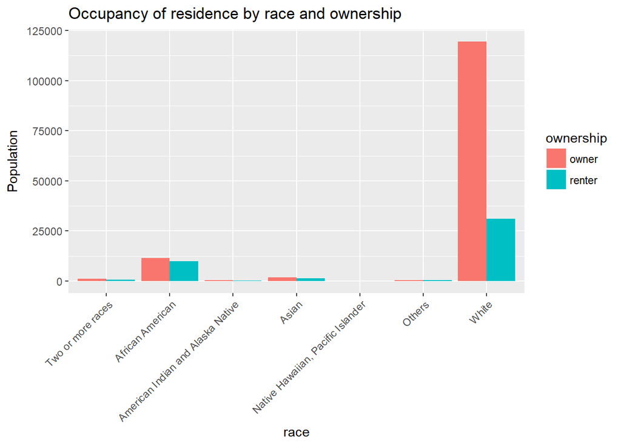

```r
ggplot(HouseData, aes(race, population)) + geom_bar(aes(fill = ownership),
    stat = "identity", position = "dodge") + labs(title = "Occupancy of residence by race and ownership  ",
    y = "Population") + theme(axis.text.x = element_text(angle = 45,
    hjust = 1))
```

Figure 1 shows that the white population has bigger occupancy in both owned and rental properties.

spread function is used to untidy the data again:

```r
HouseData2 <- spread(HouseData, 3, 2)
```

Figure 2:

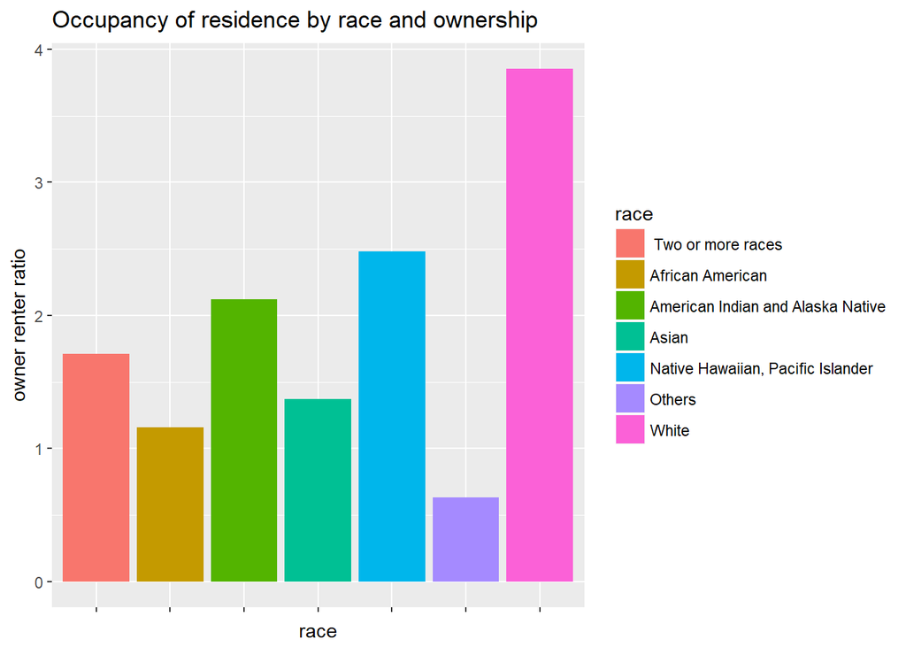

```r
ggplot(HouseData2, aes(race, owner/renter)) + geom_bar(aes(fill = race),
    stat = "identity", position = "dodge") + labs(title = "Occupancy of residence by race and ownership  ",
    y = "owner renter ratio") + theme(axis.text.x = element_blank())
```

Figure 2 shows that the ratio of white population has more house ownership compared to other races.

Figure 3:

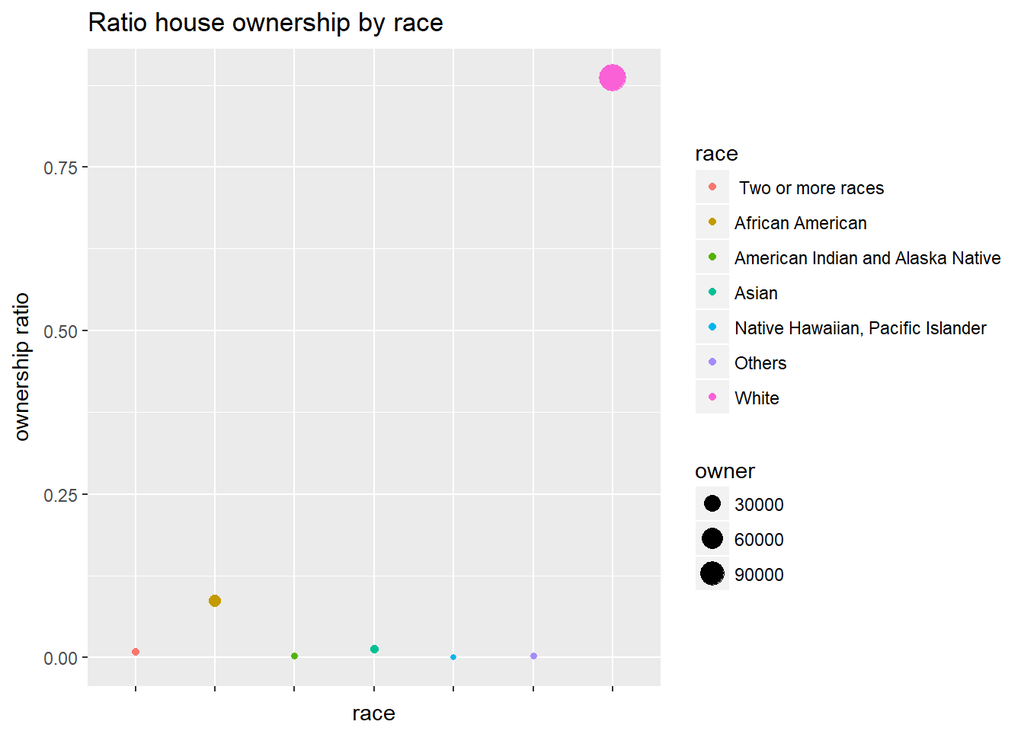

```r
ggplot(HouseData2, aes(x = race, y = owner/sum(owner))) + geom_point(aes(color = race,
    size = owner)) + labs(title = "Ratio house ownership by race",
    y = "ownership ratio") + theme(axis.text.x = element_blank())
```

Figure 3 also suggest the white population has a bigger percentage of home ownership while african american population hold the distant second position.